# Практическая работа 2 - Графики и кластеризация

Цель работы: Составить графики, проанализировать их и провести кластеризацию.

Для начала импортируем все необходимые библиотеки

```python
import pandas as pd
import numpy as np

import seaborn as sns
import matplotlib.pyplot as plt
```

Запишем датасет в переменную

```python
df = pd.read_csv('Prakticheskay1_clear.csv') #чтение csv в переменную
df
```

|  | Unnamed: 0 | Rank | Name | Platform | Year | Genre | Publisher | NA_Sales | EU_Sales | JP_Sales | Other_Sales | Global_Sales |
| --- | --- | --- | --- | --- | --- | --- | --- | --- | --- | --- | --- | --- |
| 0 | 0 | 13292 | E.X. Troopers | PS3 | 2012.0 | Shooter | Capcom | 0.00 | 0.00 | 0.05 | 0.00 | 0.05 |
| 1 | 1 | 15041 | Steins;Gate: Senkei Kousoku no Phonogram | X360 | 2013.0 | Adventure | 5pb | 0.00 | 0.00 | 0.02 | 0.00 | 0.02 |
| 2 | 2 | 15717 | This War of Mine | PS4 | 2016.0 | Action | Deep Silver | 0.00 | 0.01 | 0.00 | 0.00 | 0.02 |
| 3 | 3 | 14047 | Kiniro no Corda 2 f | PSP | 2009.0 | Role-Playing | Tecmo Koei | 0.00 | 0.00 | 0.04 | 0.00 | 0.04 |
| 4 | 4 | 5127 | Turok: Rage Wars | N64 | 1999.0 | Shooter | Acclaim Entertainment | 0.30 | 0.06 | 0.00 | 0.00 | 0.37 |
| ... | ... | ... | ... | ... | ... | ... | ... | ... | ... | ... | ... | ... |
| 537 | 548 | 12286 | My Pet Chimp | DS | 2010.0 | Simulation | 505 Games | 0.06 | 0.00 | 0.00 | 0.00 | 0.06 |
| 538 | 549 | 10521 | God Eater 2: Rage Burst | PS4 | 2015.0 | Role-Playing | Namco Bandai Games | 0.00 | 0.01 | 0.09 | 0.00 | 0.10 |
| 539 | 550 | 4981 | Triple Play 97 | PS | 1996.0 | Sports | Electronic Arts Victor | 0.21 | 0.15 | 0.00 | 0.03 | 0.38 |
| 540 | 551 | 1157 | Dragon Quest V: Hand of the Heavenly Bride | DS | 2008.0 | Role-Playing | Square Enix | 0.19 | 0.02 | 1.36 | 0.02 | 1.60 |
| 541 | 552 | 10192 | Tales of Phantasia (PS1 & PSP Versions) | PSP | 2006.0 | Role-Playing | Namco Bandai Games | 0.00 | 0.00 | 0.11 | 0.00 | 0.11 |

542 rows × 12 columns

Рассмотрим несколько видов графиков, предоставленных бибилиотекой pyplot

"Countplot" – это график, который отображает количество вхождений каждого уникального значения в столбце или строке набора данных. Для каждого уникального значения создается столбец на гистограмме, показывающий частоту его появления.

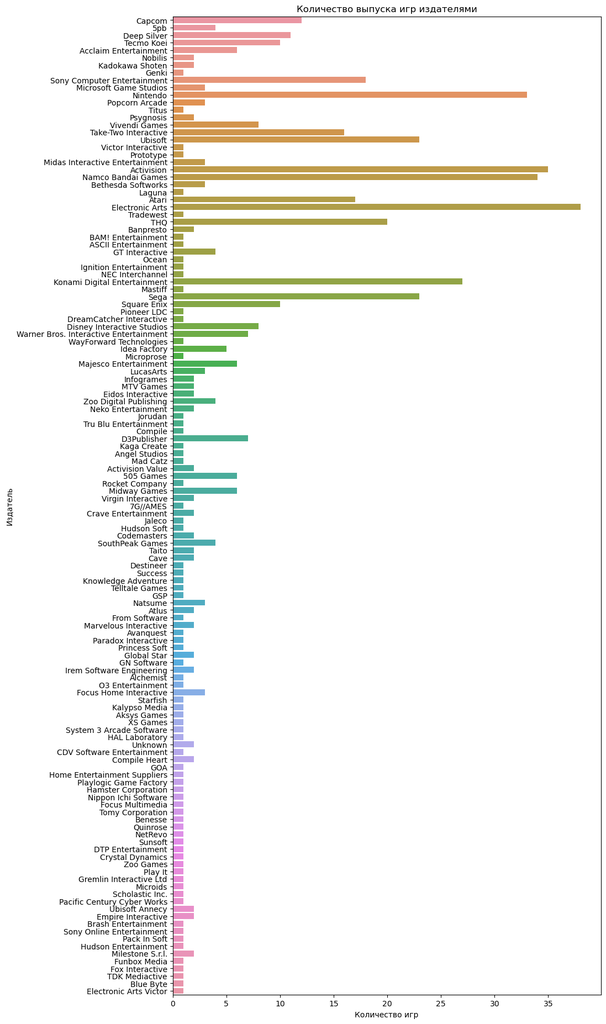

```python
# Создание графика с указанием размера
plt.figure(figsize=(10, 23))

# Установка заголовка графика
plt.title("Количество выпуска игр издателями")

# Создание countplot с указанием столбца данных
sns.countplot(y=df.Publisher)

# Установка подписи оси x
plt.xlabel("Количество игр")

# Установка подписи оси y
plt.ylabel("Издатель")
```

Из данного графика можно сделать вывод, что основную долю выпущенных игр занимают крупные игровые компании, такие как "Electronic Arts", "Activision", а также несколько других издателей. Эти компании выпустили гораздо больше игр, чем остальные, и их названия широко известны в игровой индустрии.

График "barplot" представляет средние значения категориальных данных визуально. Для каждого уникального значения в столбце или строке, "barplot" создает отдельный столбец или строку, где высота каждого столбца или строки соответствует среднему значению переменной. Таким образом, "barplot" позволяет сравнивать и анализировать средние значения для разных категорий и выявлять возможные различия между ними.

[output not shown]

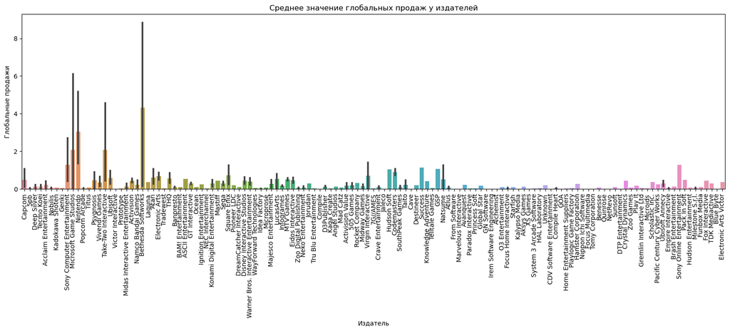

```python
# Создание фигуры с указанным размером
plt.figure(figsize=(20, 5))

# Установка заголовка графика
plt.title("Среднее значение глобальных продаж у издателей")

# Создание barplot с указанием оси x (издатель) и оси y (глобальные продажи)
sns.barplot(x=df.Publisher, y=df.Global_Sales)

# Установка подписи оси x
plt.xlabel("Издатель")

# Установка подписи оси y
plt.ylabel("Глобальные продажи")

# Поворот подписей на оси x для лучшей читаемости
plt.xticks(rotation=90)
```

График "ящик с усами" (boxplot) представляет собой визуализацию, которая наглядно демонстрирует основные характеристики распределения данных. Он включает в себя пятикратный диапазон значений, отображая минимальное значение, первый квартиль, медиану, третий квартиль и максимальное значение. Кроме того, на графике могут быть выделены выбросы - отдельные точки, которые находятся за пределами пятикратного диапазона.

[output not shown]

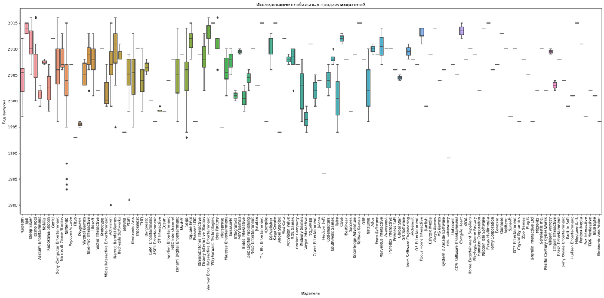

```python
# Создание фигуры с указанным размером
plt.figure(figsize=(28, 10))

# Установка заголовка графика
plt.title("Исследование глобальных продаж издателей")

# Создание boxplot с указанием данных и осей x и y
sns.boxplot(data=df, x='Publisher', y='Year')

# Установка подписи оси x
plt.xlabel("Издатель")

# Установка подписи оси y
plt.ylabel("Год выпуска")

# Поворот подписей на оси x для лучшей читаемости
plt.xticks(rotation=90)
```

# Тепловая карта корреляции - heatmap

Тепловая карта (heatmap) представляет данные в виде цветовой матрицы, где каждое значение отображается определенным цветом, отражающим его величину или степень. Она часто используется для визуализации двумерных данных, где значения различных ячеек матрицы представлены различными цветовыми оттенками, отражающими их числовые значения.

```python
df.corr() #Вычисление матрицы корреляций между числовыми столбцами в датасете
```

|  | Unnamed: 0 | Rank | Year | NA_Sales | EU_Sales | JP_Sales | Other_Sales | Global_Sales |
| --- | --- | --- | --- | --- | --- | --- | --- | --- |
| Unnamed: 0 | 1.000000 | 0.043695 | 0.001551 | -0.055494 | -0.004169 | 0.035970 | 0.006400 | -0.034603 |
| Rank | 0.043695 | 1.000000 | 0.209881 | -0.312700 | -0.412331 | -0.323105 | -0.404692 | -0.412007 |
| Year | 0.001551 | 0.209881 | 1.000000 | -0.150456 | 0.043474 | -0.187576 | 0.066216 | -0.112850 |
| NA_Sales | -0.055494 | -0.312700 | -0.150456 | 1.000000 | 0.509716 | 0.272285 | 0.537047 | 0.924096 |
| EU_Sales | -0.004169 | -0.412331 | 0.043474 | 0.509716 | 1.000000 | 0.490629 | 0.952393 | 0.783847 |
| JP_Sales | 0.035970 | -0.323105 | -0.187576 | 0.272285 | 0.490629 | 1.000000 | 0.436147 | 0.500353 |
| Other_Sales | 0.006400 | -0.404692 | 0.066216 | 0.537047 | 0.952393 | 0.436147 | 1.000000 | 0.786297 |
| Global_Sales | -0.034603 | -0.412007 | -0.112850 | 0.924096 | 0.783847 | 0.500353 | 0.786297 | 1.000000 |

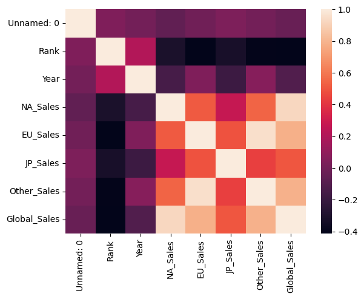

```python
sns.heatmap(df.corr()) #Создание тепловой карты корреляционной матрицы
```

Анализируя данный график, мы можем сделать следующие выводы о взаимосвязи переменных:

Сетка графиков представляет собой набор графиков, расположенных в виде таблицы, которая отображает зависимости между парами переменных в наборе данных. Каждый график в сетке показывает разброс точек, представляющих соответствующую пару переменных и помогает исследовать взаимосвязи и паттерны между ними.

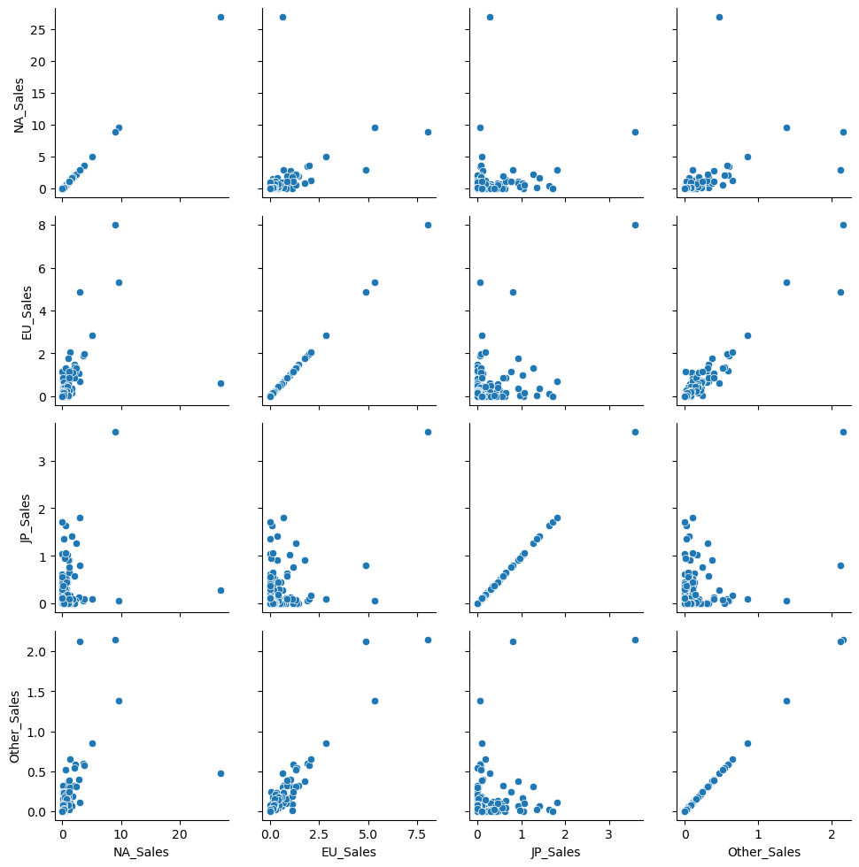

```python
# Создание сетки графиков с выбранными переменными
g = sns.PairGrid(df[["NA_Sales", "EU_Sales", "JP_Sales", "Other_Sales"]])

# Настройка типа графика для каждой пары переменных (scatterplot)
g.map(sns.scatterplot)
```

K-means является алгоритмом кластеризации, который применяется для разделения больших наборов данных на группы схожих объектов. Основная цель этого алгоритма заключается в минимизации суммарного квадратичного отклонения между точками внутри каждого кластера и его центроидов.

```python
#Подключение бибилиотеки k-means
from sklearn.cluster import KMeans
```

```python
minidf = df[["JP_Sales", "Other_Sales", "Global_Sales"]].iloc[::4]
minidf
```

|  | JP_Sales | Other_Sales | Global_Sales |
| --- | --- | --- | --- |
| 0 | 0.05 | 0.00 | 0.05 |
| 4 | 0.00 | 0.00 | 0.37 |
| 8 | 0.00 | 0.01 | 0.04 |
| 12 | 0.00 | 0.00 | 0.04 |
| 16 | 0.09 | 0.57 | 6.34 |
| ... | ... | ... | ... |
| 524 | 0.04 | 0.00 | 0.04 |
| 528 | 0.00 | 0.00 | 0.06 |
| 532 | 0.00 | 0.08 | 0.42 |
| 536 | 0.00 | 0.00 | 0.02 |
| 540 | 1.36 | 0.02 | 1.60 |

136 rows × 3 columns

В данном коде создается экземпляр модели KMeans с заданным количеством кластеров равным 4. Затем модель применяется на наборе данных minidf с использованием метода fit_predict() для получения предсказанных меток кластеров для каждой точки данных. Далее, в minidf добавляется столбец "KMeans", содержащий предсказанные метки кластеров. Наконец, выводится minidf с добавленным столбцом "KMeans" для визуализации результатов кластеризации.

```python
# Создание экземпляра модели KMeans с указанием количества кластеров равным 4
model = KMeans(n_clusters=4)

# Применение модели на наборе данных minidf и получение предсказанных меток кластеров
all_pred = model.fit_predict(minidf)

# Добавление столбца "KMeans" в minidf, содержащего предсказанные метки кластеров
minidf["KMeans"] = all_pred

# Вывод minidf с добавленным столбцом "KMeans"
minidf
```

|  | JP_Sales | Other_Sales | Global_Sales | KMeans |
| --- | --- | --- | --- | --- |
| 0 | 0.05 | 0.00 | 0.05 | 0 |
| 4 | 0.00 | 0.00 | 0.37 | 0 |
| 8 | 0.00 | 0.01 | 0.04 | 0 |
| 12 | 0.00 | 0.00 | 0.04 | 0 |
| 16 | 0.09 | 0.57 | 6.34 | 1 |
| ... | ... | ... | ... | ... |
| 524 | 0.04 | 0.00 | 0.04 | 0 |
| 528 | 0.00 | 0.00 | 0.06 | 0 |
| 532 | 0.00 | 0.08 | 0.42 | 0 |
| 536 | 0.00 | 0.00 | 0.02 | 0 |
| 540 | 1.36 | 0.02 | 1.60 | 2 |

136 rows × 4 columns

В этом коде создается экземпляр PairGrid с использованием minidf в качестве данных и параметра hue="KMeans", который указывает на столбец "KMeans" в minidf, который будет использоваться для раскраски точек на графиках. Затем метод map() применяет scatterplot к каждой паре переменных в PairGrid, чтобы визуализировать их распределение и взаимосвязь с помощью точечных графиков.

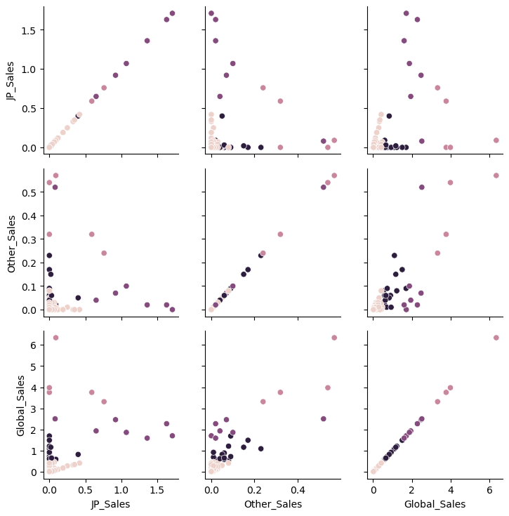

```python
# Создание экземпляра PairGrid с использованием minidf и параметром hue="KMeans"
g = sns.PairGrid(minidf, hue="KMeans")

# Применение scatterplot к каждой паре переменных в PairGrid
g.map(sns.scatterplot)
```

Для создания круговой диаграммы - PieChart необходимо имользовать метод pie библиотеки pyplot, затем необзодимо выбрать, по какому значению стоит группировать значения, в нашем случае мы будет группировать по Платформам, на которые выпускаются игры

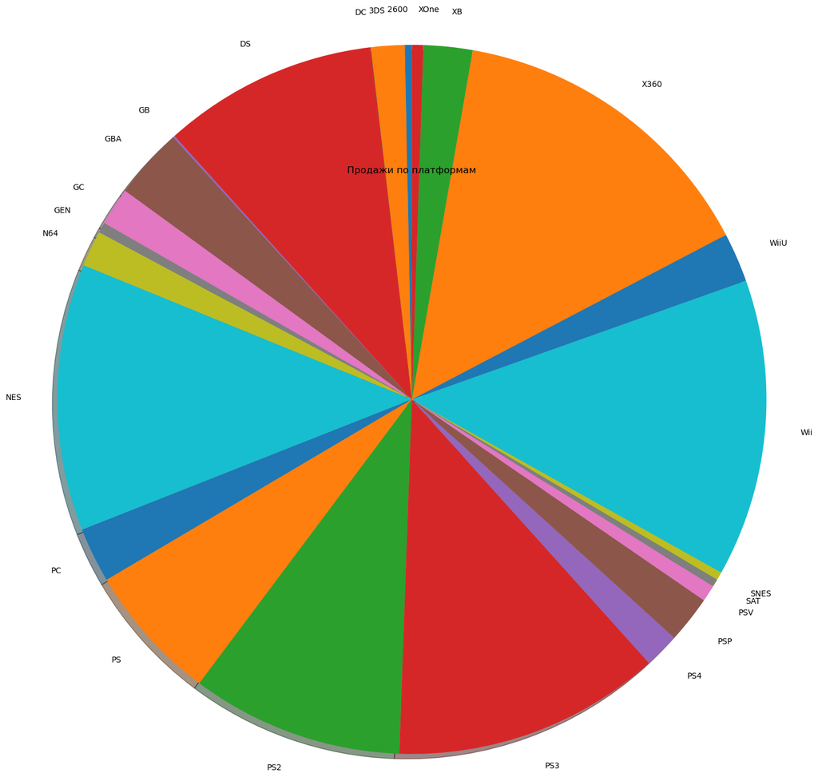

```python
plt.figure(figsize=(28, 10))

# Группировка данных по столбцу 'Platform' и вычисление суммы глобальных продаж для каждой платформы
platform_sales = df.groupby('Platform')['Global_Sales'].sum()

# Построение круговой диаграммы с использованием данных platform_sales
plt.pie(platform_sales, labels=platform_sales.index , startangle=90, labeldistance=1.1, shadow=True, radius=2)

# Заголовок диаграммы
plt.title('Продажи по платформам')
```

Вспользуемся уже созданной ранее переменной, для того, чтобы показать на линейном графике продажи, данный график являеется менее привлекательным, чем круговая диаграмма, но зато по нему проще опрделять значения в количественном соотношении

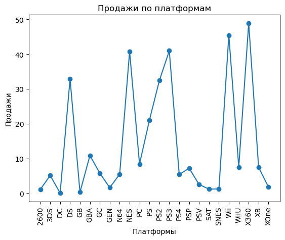

```python
# Преобразование индекса platform_sales в список жанров
genres = platform_sales.index.tolist()

# Преобразование значений platform_sales в список продаж
sales = platform_sales.tolist()

# Построение графика с использованием списков genres и sales, с маркерами 'o'
plt.plot(genres, sales, marker='o')

# Заголовок графика
plt.title('Продажи по платформам')

# Наименование оси x
plt.xlabel('Платформы')

# Наименование оси y
plt.ylabel('Продажи')

# Поворот меток на оси x для удобного чтения
plt.xticks(rotation=90)

# Отображение графика
plt.show()
```

DBSCAN (Density-Based Spatial Clustering of Applications with Noise) - это алгоритм машинного обучения без учителя, используемый для кластеризации пространственных данных на основе плотности. Он объединяет точки данных, находящиеся близко друг к другу в области высокой плотности, и отделяет их от областей низкой плотности.

1)DBSCAN из модуля sklearn.cluster, который содержит реализацию алгоритма DBSCAN для кластеризации данных.

```python
from sklearn.cluster import DBSCAN
from sklearn.preprocessing import StandardScaler
```

```python
# Выбираем интересующие нас признаки для анализа
selected_features = ['EU_Sales', 'Other_Sales', 'Global_Sales']

# Создаем новый датафрейм, содержащий только выбранные признаки
data = df[selected_features]

# Создаем объект StandardScaler для масштабирования данных
scaler = StandardScaler()

# Масштабируем данные путем преобразования их к стандартному нормальному распределению
scaled_data = scaler.fit_transform(data)

# Создаем объект DBSCAN для выполнения кластеризации с заданными параметрами
dbscan = DBSCAN(eps=0.5, min_samples=5)

# Применяем алгоритм DBSCAN к данным
dbscan.fit(data)
```

```
DBSCAN()
```

1)labels содержит метки кластеров, присвоенные каждой точке данных после выполнения DBSCAN.

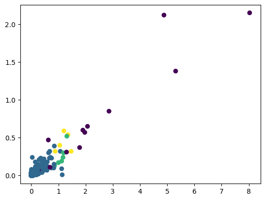

```python
labels = dbscan.labels_

# Создаем scatter plot для визуализации кластеров
plt.scatter(data['EU_Sales'], data['Other_Sales'], c=labels, cmap='viridis')
```

# Вывод:

В процессе моей работы я использовал разнообразные методы визуализации и кластеризации данных, такие как countplot, barplot, boxplot, heatmap, pairgrid, Pie, Line и DBSCAN. Анализируя полученные результаты, я пришел к выводу, что использование такого разнообразия методов позволяет более глубоко изучить данные и выявить важные паттерны, тренды и взаимосвязи между переменными. Это важно для принятия информированных решений и формулирования выводов на основе анализа данных.